# Soil Water Status Tools - prototype visualizations

Amanda Pennino

2026-01-12

# Introduction

This document presents prototype visualizations for soil water status tools using USDA-NRCS SCAN (Soil Climate Analysis Network) data. The goal is to provide tiered complexity tools to visualize soil moisture conditions and for assessing flood and drought risk. The following exercises are shown for a single date (08-16-2007) at Walnut Gulch (SCAN Site ID: 2026).

**Current Limitations**  
* Does not account for frozen soil conditions  
* Rock fragment % not removed from storage calculations

**Outline**  
I. OVERVIEW - At a glance, snapshot indicators for producers/extension  
II. TRENDS - Trajectory tools for conservation for planners/advisors  
III. ANALYSIS - Technical interpretation for researchers

```r
#======================================
# LOAD PACKAGES
#======================================
library(tidyverse)
library(lubridate)
library(soilDB)
library(aqp)
library(viridis)
library(knitr)
library(kableExtra)


#======================================
# LOAD DATA
#======================================
m <- SCAN_site_metadata(site.code = c(2026)) #Walnut Creek, AZ

# Fetch data
x <- fetchSCAN(
  site.code = 2026,
  timeseries = "Daily",
  year = c(2000:2024))

# Pull KSSL lab sample number for pedon data
kssl <- fetchKSSL(pedlabsampnum = x$metadata$pedlabsampnum, returnMorphologicData = FALSE)

# Soil Moisture Sensors
SMS <- x[["SMS"]]
```

# I. OVERVIEW

## A. Profile Water Storage

Whole-profile water storage integrates volumetric water content (VWC) across the soil depth to estimate the total amount of water stored in the profile, expressed in millimeters (mm) of water per unit area (m²). This metric is directly comparable to rainfall amounts.

**Storage Calculation:** For each soil layer $i$:

$$\text{Storage}_i =
\frac{\text{VWC}_i}{100} \times \text{Thickness}_i \times
10$$

Where:  
* $\text{VWC}_i$ = volumetric water content (%)  
* $\text{Thickness}_i$ = layer thickness (cm)  
* $10$ = conversion factor (cm to mm)

Total profile storage:

$$\text{Storage}_{\text{total}} =
\sum_{i=1}^{n} \text{Storage}_i$$

### Methodological Approaches

Two approaches are compared for calculating water storage, which differ in how soil layer thickness is defined and how potential storage capacity (total porosity) is estimated.

#### Approach 1: Sensor-based Representative Layers

**Layer Thickness Calculation:** Each sensor value represents a ‘zone of influence’ around it’s depth, extending halfway to the adjacent sensor.

**Potential Storage Estimation:** Uses the 99th percentile of historical VWC observations at each depth as an estimate of total saturation. The 99th percentile was chosen over a sensor maximum to account for potential sensor errors. When a sensor has a smaller historical record, the 95th percentile should be considered!

**Advantages:** Does not require soil horizon data (can easily take in other data streams); Uses actual sensor observations.

**Limitations:** Assumes saturation has been reached at some point; Requires multi-year historical record; Assumes sensor placement accurate represents changes across the soil profile.

#### Approach 2: Horizon-based Calculations

**Layer Thickness Calculation:** Three cases for assigning VWC values to soil horizons:

1. *One sensor in horizon:* Use that sensor’s value
2. *Multiple sensors in horizon:* Average all sensor values
3. *No sensors in horizon:* Linear interpolation/integration between bracketing sensors

For case 3, VWC per horizon is approximated by creating 20 evenly-spaced depth points and averaging interpolated VWC values.The integration uses the trapezoidal rule:

$$\text{VWC}_{\text{horizon}} =
\frac{1}{z_{\text{bottom}} - z_{\text{top}}}
\int_{z_{\text{top}}}^{z_{\text{bottom}}} \text{VWC}(z) \,
dz$$

**Potential Storage Estimation** Uses ROSETTA pedotransfer function (Schaap et al., 2001) to estimate saturated water content ($\theta_s$) from particle size distribution (sand, silt, clay percentages from KSSL data for that site).

**Advantages** Uses actual soil horizon depths; Soil-specific porosity estimates from texture; Better represents pedogenic horizons.

**Limitations** Requires lab horizon data (KSSL data); ROSETTA estimates laboratory saturation, may exceed field capacity; Interpolation assumes linear VWC gradients between sensors (representative to real life?)

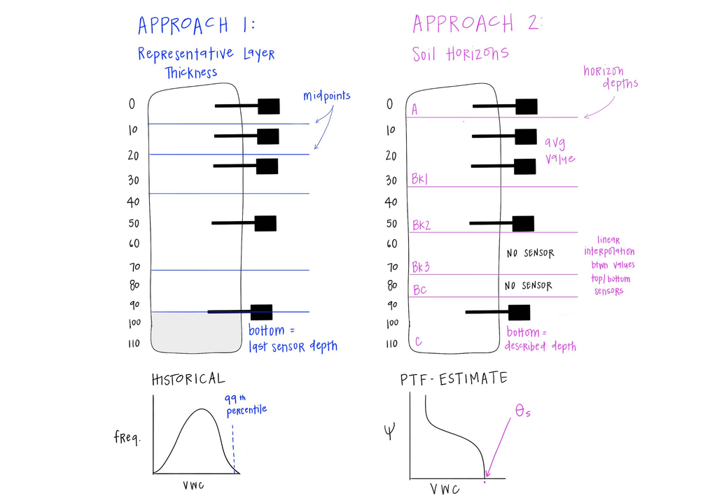

### Comparison of approaches

It appears that differences in layer definition calculations result in similar soil water storage profiles (Current Storage). When porosity calculations were included, the approaches yielded very different saturation estimates (Potential Storage).  
**Why do approaches differ?**  
* Historical maximums of vwc could include sensor errors or miss total saturation events.  
* ROSETTA estimates artificially higher than real life?  
* Differences in profile depth?

|  | Approach 1: Sensor Layers | Approach 2: Soil Horizons |
| --- | --- | --- |
| Layer Definition | Sensor zones of influence | Soil genetic horizons |
| Potential Storage | Historical 99th percentile VWC | ROSETTA PTF from texture for theta s |
| Data Required | Multi-year sensor data | Horizon data + KSSL texture |
| Best For | Sites without horizon data; real-time monitoring | Detailed soil analysis; research applications |
| Limitations | Requires long records; may miss true saturation | May overestimate field saturation |

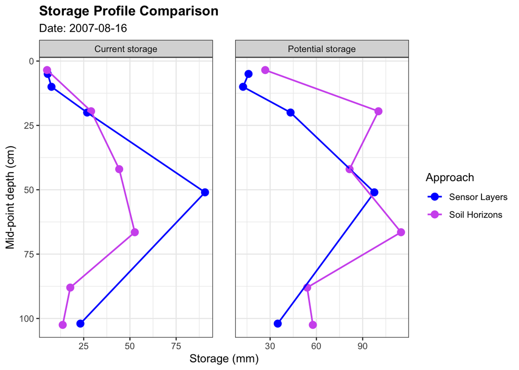

| Approach | Current_Storage_mm | Potential_Storage_mm | Pct_Full | Remaining_Capacity_mm |
| --- | --- | --- | --- | --- |
| Sensor Layers (Historical Max) | 153.8 | 204.2 | 75.3 | 50.4 |
| Soil Horizons (ROSETTA PTF) | 162.4 | 435.1 | 37.3 | 272.7 |

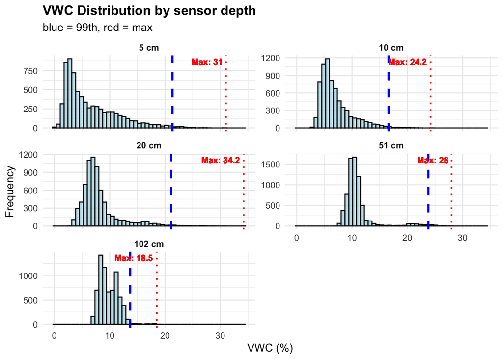

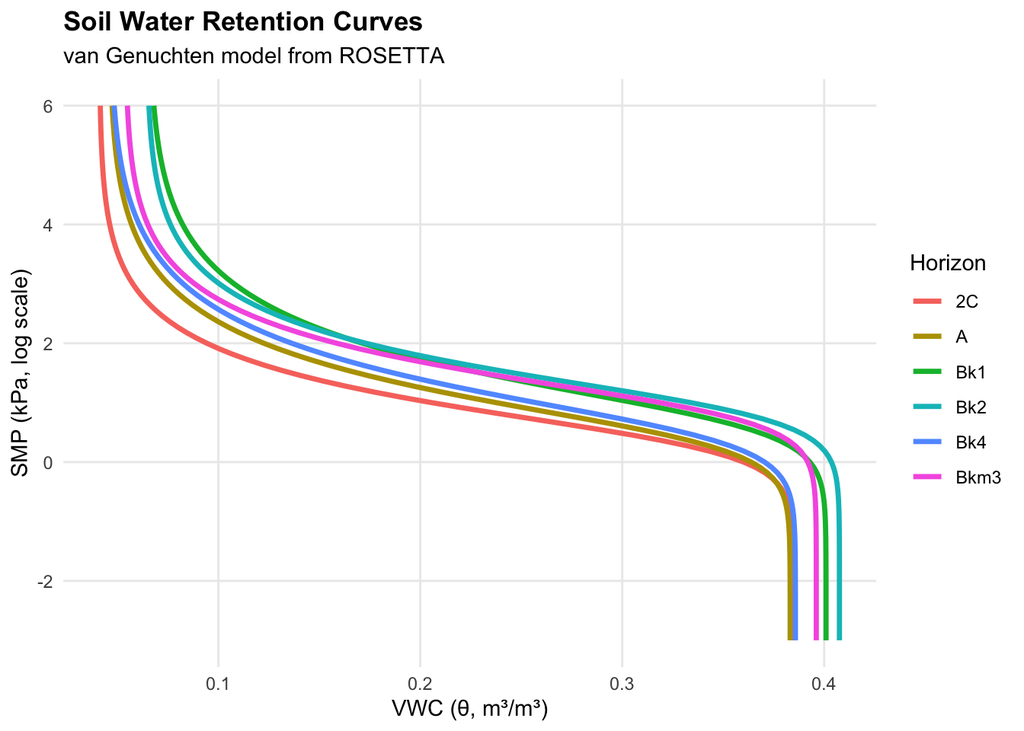

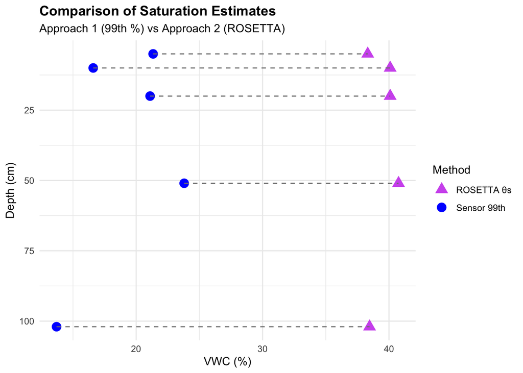

Saturation Estimate Comparison

| Depth (cm) | Horizon | Approach 1 | Approach 2 | Difference (%) |
| --- | --- | --- | --- | --- |
| 5 | A | 21.34 | 38.32 | 16.98 |
| 10 | Bk1 | 16.60 | 40.09 | 23.49 |
| 20 | Bk1 | 21.10 | 40.09 | 18.99 |
| 51 | Bk2 | 23.80 | 40.76 | 16.96 |
| 102 | 2C | 13.70 | 38.46 | 24.76 |

### Prototype visualization

Using Approach 2 for calculating soil profile water storage. The gray bar represents remaining storage capacity

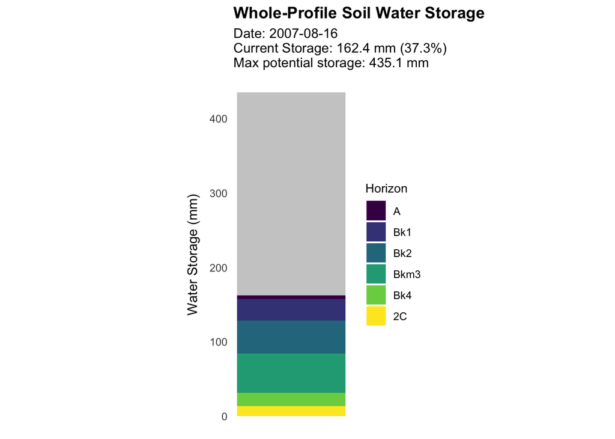

```r
#===================================
# WATER STORAGE
#===================================

summary <- comparison_profile[comparison_profile$Approach == "Soil Horizons (ROSETTA PTF)", ]

current_storage = round(summary$ Current_Storage_mm, 1)
remaining_storage = round(summary$Remaining_Capacity_mm, 1)
pct_full = round(summary$Pct_Full, 1)
total_potential = round(summary$Potential_Storage_mm, 1)

remain_df <- data.frame(
  hzn_desgn = "Remaining Storage",
  storage_mm = remaining_storage
)

test <- bind_rows(remain_df, SMS_app2)
test$hzn_desgn <- factor(test$hzn_desgn, levels = unique(test$hzn_desgn))

#Create color palette
n_horizons <- nrow(SMS_app2)
horizon_colors <- viridis::viridis(n_horizons)
colors <- c("gray80", horizon_colors)
names(colors) <- levels(test$hzn_desgn)


ggplot(test, aes(x = 0.5)) +
  geom_col(aes(y = storage_mm, fill = hzn_desgn),
           width = 0.3) +
  scale_x_continuous(limits = c(0.34,0.65), expand = c(0,0))+
  #scale_fill_manual(values = colors, name = "Horizon") +
  scale_fill_manual(
  values = colors,
  breaks = setdiff(unique(test$hzn_desgn), "Remaining Storage"),
  name = "Horizon")+
  labs(title = "Whole-Profile Soil Water Storage",
       subtitle = paste0("Date: ", current_date,"\nCurrent Storage: ", current_storage, " mm (", pct_full, "%)\n", "Max potential storage: ", total_potential, " mm"),
       x = NULL,
       y = "Water Storage (mm)") +
  theme_minimal() +
  theme(plot.title = element_text(face = "bold"),
        axis.text.x = element_blank(),
        axis.ticks.x = element_blank(),
        axis.title.y = element_text(margin = margin(r=8)),
        panel.grid = element_blank(),
        legend.title = element_text(size = 10),
        aspect.ratio = 7/2.2)
```

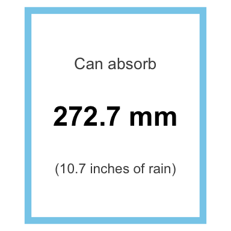

```r
#===================================
# REMAINING STORAGE
#===================================

ggplot() +
  annotate("rect",
           xmin = 0, xmax = 1,
           ymin = 0, ymax = 1,
           fill = "white", color = "#87CEEB", linewidth = 2) +
  annotate("text",
           x = 0.5, y = 0.75,
           label = "Can absorb",
           size = 3.5, color = "gray30") +
  annotate("text",
           x = 0.5, y = 0.5,
           label = paste0(remaining_storage, " mm"),
           size = 6, fontface = "bold", color = "black") +
  annotate("text",
           x = 0.5, y = 0.25,
           label = paste0("(", round(remaining_storage / 25.4, 1), " inches of rain)"),
           size = 3, color = "gray30") +
  coord_fixed(ratio = 1.2) +
  theme_void()
```

### To do

- Test different sensors and time periods. Do differences in approaches hold true?
- Validate chosen method against known saturation events (using precipitation data)
- Additional ways to estimate total porosity (other than theta-s from ROSETTA), e.g., bulk density for true porosity, water retention KSSL data, additional PTFs

## B. Storage Percentile

Percentile-based classification provides context for current soil moisture conditions by comparing to historical conditions for the same time period. This helps answer: Is the current wetness condition typical, unusually dry, or unusually wet for this time of year?

### Methodology

**Antecedent Window:** 7-day average preceding the current date

**Historical Comparison:** Same 7-day calendar windows for all years of record.

**Percentile Categories & Status Flags:**  
(i) 0-10 | Much Drier Than Average  
(ii) 10-30 | Drier Than Average  
(iii) 30-70 | Typical Conditions  
(iv) 70-90 | Wetter Than Average  
(v) 90-100 | Much Wetter Than Average

```r
#===================================
# PREVIOUS 7 DAYS STORAGE
#===================================
# Average whole-profile storage for the previous 7 days. Does not account for current day

window_days <- 7
start_date <- as.Date(current_date) - days(7)
end_date   <- as.Date(current_date) - days(1)

#Calculate storage for each date
SMS_7day <- SMS %>%
  filter(Date >= start_date & Date <= end_date) %>%
  group_by(Date) %>%
  group_modify(~ calc_horizon_vwc(horizon_dat, .x %>% dplyr::select(depth, value))) %>%
  ungroup()%>%
  select(Date, hzn_desgn, hzn_top, hzn_bot, thickness_cm, vwc, storage_mm)

# Sum storage by day
storage7day <- aggregate(storage_mm ~ Date, data = SMS_7day, FUN = sum)

# Average across 7 days
avg_storage7day <- round(mean(storage7day$storage_mm, na.rm= TRUE), 1)


#===================================
# HISTORICAL 7-DAY STORAGE
#===================================
# Average whole-profile storage for the same 7-day window across all years of available data

# Month-day window based on current_date
md_start <- format(start_date, "%m-%d")
md_end   <- format(end_date,   "%m-%d")

# Create sequence of month-days, use 2001 as dummy variable
md_seq <- format(seq.Date(as.Date(paste0("2001-", md_start)),
                          as.Date(paste0("2001-", md_end)),
                          by = 1),
                 format = "%m-%d")

# Filter to matching window across all years
SMS_7days_hist <- SMS %>%
  mutate(md = format(Date, "%m-%d")) %>%
  filter(md %in% md_seq)

# Storage for each date in record
storage7day_hist <- SMS_7days_hist %>%
  group_by(Date) %>%
  filter(sum(!is.na(value)) >= 3) %>%  # Only keep dates with 3+ sensors
  group_modify(~ {
    sensors_df <- data.frame(depth = .x$depth, value = .x$value)
    calc_horizon_vwc(horizon_dat, sensors_df)
  }) %>%
  ungroup() %>%
  select(Date, hzn_desgn, hzn_top, hzn_bot, thickness_cm, vwc, storage_mm)

# Sum storage by day (whole profile)
avg_storage7day_hist <- aggregate(storage_mm ~ Date, data = storage7day_hist, FUN = sum)

# Calculate 7-day average for every year

avg_storage7day_hist$year <- year(avg_storage7day_hist$Date)
avg_storage7day_hist_yr <- aggregate(storage_mm ~ year, data = avg_storage7day_hist, FUN = mean)


#===================================
# PERCENTILE CALCULATIONS
#===================================
# Compare 7-day average to historical distribution
current_percentile <- round(100 * mean(avg_storage7day_hist_yr$storage_mm <= avg_storage7day), 1)
```

### Prototype visualizations

*Option 1:* Gauge/Arc style  
*Option 2:* Distribution and current position (shows historical context)  
*Option 3:* Box plot (good for showing outliers)  
*Option 4:* Timeline view (NEEDS WORK)

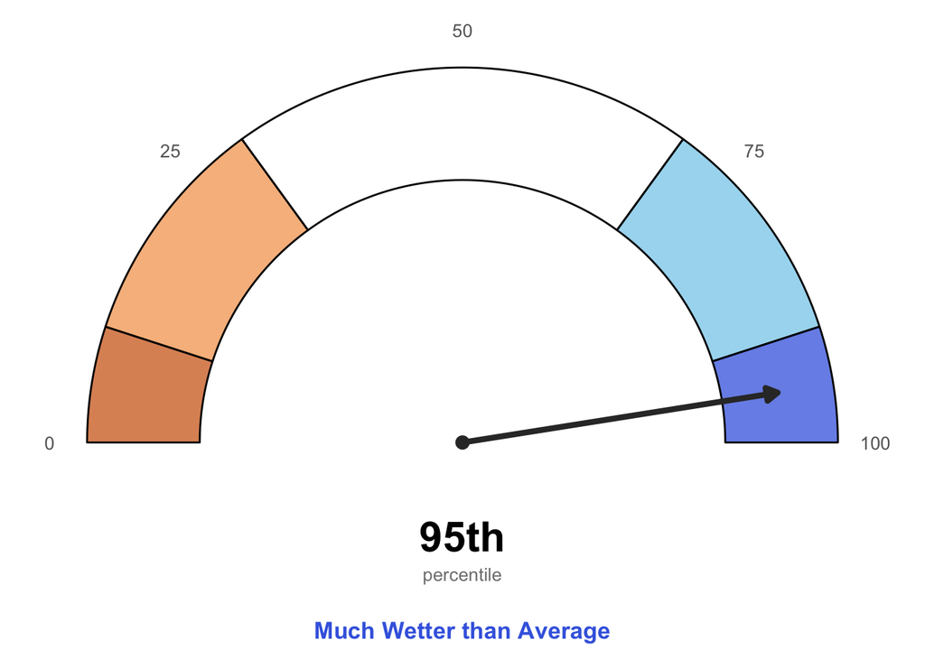

```r
#===================================
# OPTION 1: GAUGE/ARC STYLE
#===================================

library(ggforce)


gauge_zones <- data.frame(
  zone = c("Much Drier than Average", "Drier than Average", "Typical Conditions", "Wetter than Average", "Much Wetter than Average"),
  start_pct = c(0, 10, 30, 70, 90),
  end_pct = c(10, 30, 70, 90, 100)) %>%
  mutate(
    # Semicircle from 0 to pi (0% on left, 100% on right)
    start = (start_pct / 100) * pi,
    end = (end_pct / 100) * pi)

gauge_zones$zone <- factor(gauge_zones$zone, levels = c("Much Drier than Average", "Drier than Average", "Typical Conditions", "Wetter than Average", "Much Wetter than Average"))

color = c("#D2691E", "#F4A460", "white","#87CEEB", "#4169E1")

# Create needle angle
needle_angle <- pi - (current_percentile / 100 * pi)
needle_end_x <- 1 + 0.85 * cos(needle_angle)
needle_end_y <- 1 + 0.85 * sin(needle_angle)


#Set status
# Define percentile categories
get_status_flag <- function(percentile) {
  if (percentile <= 10) return(list(label = "Much Drier than Average", color = "#D2691E"))
  if (percentile <= 30) return(list(label = "Drier than Average", color = "#F4A460"))
  if (percentile <= 70) return(list(label = "Typical Conditions", color = "black"))
  if (percentile <= 90) return(list(label = "Wetter than Average", color = "#87CEEB"))
  return(list(label = "Much Wetter than Average", color = "#4169E1"))
}

status <- get_status_flag(current_percentile)

ggplot() +
  # Zones of wetness
  geom_arc_bar(
    data = gauge_zones,
    aes(x0 = 1, y0 = 1,
        r0 = 0.7, r = 1,
        start = start - pi / 2,
        end = end - pi / 2,
        fill = zone
        ),
    alpha = 0.75
    ) +
  coord_fixed() +
  scale_fill_manual(values = color) +
  # Needle
  geom_segment(aes(x = 1, y = 1,
                   xend = needle_end_x,
                   yend = needle_end_y
                   ),
               linewidth = 1.5,
               color = "gray20",
               arrow = arrow(length = unit(0.25, "cm"), type = "closed")) +
  # Needle pivot point
  geom_point(aes(x = 1, y = 1),
             size = 3,
             color = "gray20"
  ) +
  # Percentile labels
  annotate(
    "text",
    x = 1 + 1.1 * cos(pi - (c(0, 25, 50, 75, 100) / 100 * pi)),
    y = 1 + 1.1 * sin(pi - (c(0, 25, 50, 75, 100) / 100 * pi)),
    label = c("0", "25", "50", "75", "100"),
    size = 3.5,
    color = "gray40"
  ) +
  # Center text - percentile value
  annotate(
    "text",
    x = 1,
    y = 0.75,
    label = paste0(current_percentile, "th"),
    size = 8,
    fontface = "bold",
    color = "black"
  ) +
  # Percentile" label
  annotate(
    "text",
    x = 1,
    y = 0.65,
    label = "percentile",
    size = 3.5,
    color = "gray50"
  ) +
  #Status label
  annotate(
    "text",
    x = 1,
    y = 0.5,
    label = status$label,
    size = 4.5,
    fontface = "bold",
    color = status$color
  ) +
  theme_void() +
  theme(
    legend.position = "none"
  )
```

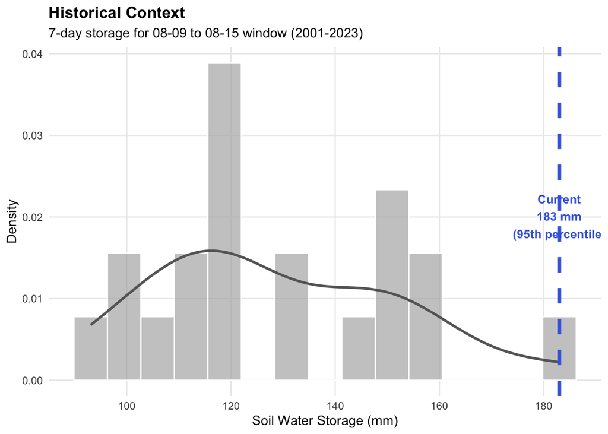

```r
#===================================
# OPTION 2: DISTRIBUTION & POSITION
#===================================

ggplot(avg_storage7day_hist_yr, aes(x = storage_mm)) +
  geom_histogram(aes(y = after_stat(density)),
                 bins = 15, fill = "gray70", color = "white", alpha = 0.7) +
  geom_density(color = "gray40", linewidth = 1) +
  geom_vline(xintercept = avg_storage7day,
             color = status$color, linewidth = 1.5, linetype = "dashed") +
  # Current value
  annotate("text",
           x = avg_storage7day,
           y = max(density(avg_storage7day_hist_yr$storage_mm)$y) * 1.1,
           label = paste0("Current\n", avg_storage7day, " mm\n(", current_percentile, "th percentile)"),
           color = status$color, fontface = "bold", size = 3.5, vjust = 0) +
  labs(title = "Historical Context",
       subtitle = paste0("7-day storage for ", md_start, " to ", md_end, " window (",
                        min(avg_storage7day_hist_yr$year), "-",
                        max(avg_storage7day_hist_yr$year), ")"),
       x = "Soil Water Storage (mm)",
       y = "Density") +
  theme_minimal() +
  theme(
    plot.title = element_text(face = "bold"),
    panel.grid.minor = element_blank()
  )
```

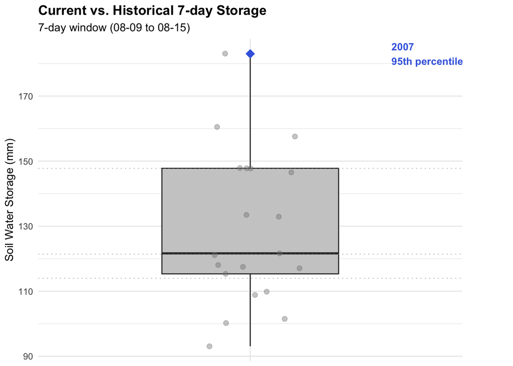

```r
#===================================
# OPTION 3: BOX PLOT
#===================================

# Current year's value
current_year_data <- data.frame(
  year = year(current_date),
  storage_mm = avg_storage7day,
  is_current = TRUE
)

hist_with_current <- avg_storage7day_hist_yr %>%
  mutate(is_current = FALSE) %>%
  bind_rows(current_year_data)

ggplot(hist_with_current, aes(x = "", y = storage_mm)) +
  geom_boxplot(fill = "gray80", outlier.shape = NA, width = 0.5) +
  geom_jitter(data = filter(hist_with_current, !is_current),
              width = 0.15, alpha = 0.4, size = 2, color = "gray50") +
  geom_point(data = filter(hist_with_current, is_current),
             size = 4, color = status$color, shape = 18) +
  # Percentile lines
  geom_hline(yintercept = quantile(avg_storage7day_hist_yr$storage_mm, c(0.25, 0.5, 0.75)),
             linetype = "dotted", color = "gray60", alpha = 0.5) +
  # Label
  annotate("text", x = 1.4, y = avg_storage7day,
           label = paste0(year(current_date), "\n", current_percentile, "th percentile"),
           color = status$color, fontface = "bold", size = 3.5, hjust = 0) +
  coord_cartesian(clip = "off") +
  labs(title = "Current vs. Historical 7-day Storage",
       subtitle = paste0("7-day window (", md_start, " to ", md_end, ")"),
       y = "Soil Water Storage (mm)",
       x = NULL) +
  theme_minimal() +
  theme(
    plot.title = element_text(face = "bold"),
    plot.margin = margin(5, 50, 5, 5),
    axis.text.x = element_blank()
  )
```

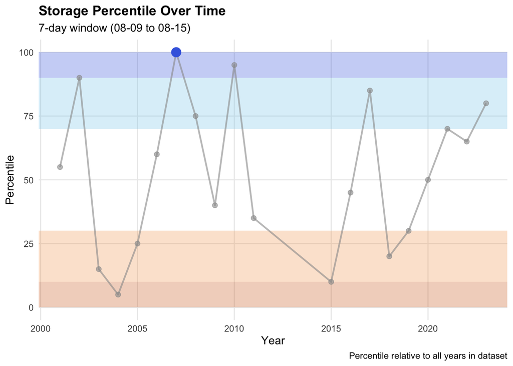

```r
#===================================
# OPTION 4: Timeline of storage %-ile
#===================================

get_percentile <- ecdf(avg_storage7day_hist_yr$storage_mm)

timeline_data <- avg_storage7day_hist_yr %>%
  mutate(percentile = round(get_percentile(storage_mm) * 100, 1),
         is_current = year == year(current_date))


ggplot(timeline_data, aes(x = year, y = percentile)) +
  # Reference bands
  annotate("rect", xmin = -Inf, xmax = Inf, ymin = 0, ymax = 10,
           fill = "#D2691E", alpha = 0.3) +
  annotate("rect", xmin = -Inf, xmax = Inf, ymin = 10, ymax = 30,
           fill = "#F4A460", alpha = 0.3) +
  annotate("rect", xmin = -Inf, xmax = Inf, ymin = 70, ymax = 90,
           fill = "#87CEEB", alpha = 0.3) +
  annotate("rect", xmin = -Inf, xmax = Inf, ymin = 90, ymax = 100,
           fill = "#4169E1", alpha = 0.3) +
  # Line through years
  geom_line(color = "gray60", linewidth = 0.8, alpha = 0.6) +
  geom_point(data = filter(timeline_data, !is_current),
             color = "gray60", size = 2, alpha = 0.6) +
  # Current year highlighted
  geom_point(data = filter(timeline_data, is_current),
             color = status$color, size = 4) +
  scale_y_continuous(limits = c(0, 100), breaks = seq(0, 100, 25)) +
  labs(title = "Storage Percentile Over Time",
       subtitle = paste0("7-day window (", md_start, " to ", md_end, ")"),
       x = "Year",
       y = "Percentile",
       caption = "Percentile relative to all years in dataset") +
  theme_minimal() +
  theme(plot.title = element_text(face = "bold"),
        panel.grid.minor = element_blank())
```

### To do

Notes:  
* 7-day window (default): Add option for 14-days, seasonal window, user-defined window  
* Depth categories? Currently whole profile.  
* Add way to view years used in historical calculation, and % skipped dates in the calculations.

## C. Additional “Overview” tools?

**Data Quality Table**  
* Current Date  
* Sensors active (e.g., 5/5)  
* Historical record (2000-2023; 23 years)  
* Data completeness (e.g., 93%)

**Download Summary**  
* A print out a conservation planner can bring with them to a site visit.

# II. TRENDS

To understand soil moisture (and temperature?) trajectory. Target users could be conservation planners, crop advisors, irrigation managers. Aims to answer the questions: Are soils drying, recharging, or stable? And how fast are these changes occurring?

## A. Timeseries of Storage

Daily whole-profile water storage over x window.

### Prototype visualizations

*Option 1:* Simple line plot (30, 60, or 90-day window), highlight current date/value  
*Option 2:* Time series with color-coded historical percentile bands. Similar to Option 4 in Storage percentiles.  
With precipitation overlay? Bars at top

### To Do

- Decide on default window
- Missing data handling
- Add smoothing option (7-day moving average?)

## B. Rate of Change

- Drying/Recharge rates (time series with trendline 7-day), mm/day change
- Could be paired with 7-day average storage

## C. Historical Distributions

## D. Threshold Exceedence

- Metrics: Consecutive days below x%, Days above field capacity
- Heatmap calendar, cumulative days bar chart
- Anomolies: Departures from normal (bar chart with horizontal bars showing +/-mm from median historical value)

# III. ANALYSIS

## A. Storm Response Analysis

- Average wet up rate for user-defined total rain/time?
- Total storm contributions

## B. Site Comparisons

- User defined-site comparisons e.g., Site 2026 and Site 179
- Comparisons of metrics between ecosystems/LRRs - Use historical precipitaiton and temperature data to classify sites into Whittaker Biomes!

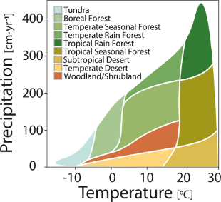

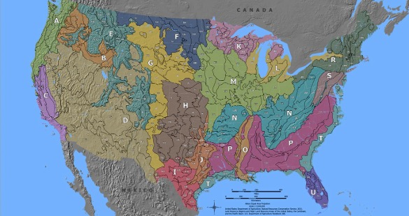

```r
# Density ridges plot
#
#library(ggridges)

# ggplot(SMS_with_p99, aes(x = value, y = factor(depth), fill = factor(depth))) +
#   geom_density_ridges(alpha = 0.6, scale = 0.9) +
#   geom_segment(
#     data = vwc_max_by_depth,
#     aes(x = p99, xend = p99, y = as.numeric(factor(depth)),
#         yend = as.numeric(factor(depth)) + 0.9),
#     color = "red", linetype = "dashed", linewidth = 1) +
#   geom_text(
#     data = vwc_max_by_depth,
#     aes(x = p99, y = as.numeric(factor(depth)) + 0.5,
#         label = round(p99, 1)),
#     hjust = -0.2, size = 3, color = "red", fontface = "bold") +
#   scale_y_discrete(labels = function(x) paste(x, "cm")) +
#   labs(title = "VWC Distribution by Depth",
#     subtitle = "Vertical lines show 99th percentile values",
#     x = "VWC (%)",
#     y = "Sensor Depth") +
#   theme_minimal() +
#   theme(plot.title = element_text(face = "bold"),
#         legend.position = "none")



##### Option 2 for water retention curves
#
# ggplot(data = res, aes(x = log10(phi), y = theta, color = hzn)) +
#   geom_line(linewidth = 1.2) +
#   # Mark key points
#   geom_vline(xintercept = log10(33), linetype = "dashed",
#              color = "blue", alpha = 0.5) +
#   geom_vline(xintercept = log10(1500), linetype = "dashed",
#              color = "red", alpha = 0.5) +
#   # Mark saturation points
#   geom_point(data = res %>% group_by(hzn) %>% slice(1),
#              aes(x = log10(phi), y = theta), size = 3) +
#   annotate("text", x = log10(33), y = max(res$theta) * 0.95,
#            label = "FC", hjust = -0.2, size = 3, color = "blue") +
#   annotate("text", x = log10(1500), y = max(res$theta) * 0.95,
#            label = "WP", hjust = -0.2, size = 3, color = "red") +
#   scale_x_continuous(
#     breaks = log10(c(0.001, 0.1, 1, 10, 33, 100, 1500, 100000)),
#     labels = c("0.001", "0.1", "1", "10", "33", "100", "1500", "100k")
#   ) +
#   labs(
#     title = "Soil Water Retention Curves",
#     subtitle = "Points at left show saturation (θs values used for potential storage)",
#     x = "Suction (kPa, log scale)",
#     y = "Volumetric Water Content (θ, m³/m³)",
#     color = "Horizon"
#   ) +
#   theme_minimal() +
#   theme(
#     plot.title = element_text(face = "bold"),
#     panel.grid.minor = element_blank()
#   )
#
```